# KNN_clasification

Irving

2025-03-20

```r
library(GGally)
library(dplyr)
library(tidyverse)
library(class)
library(ggplot2)
library(caret)
library(MLmetrics)
```

4. Haga un modelo de clasificación, use la variable categórica que hizo con el precio de las casas (barata, media y cara) como variable respuesta.

```
## Resumen del modelo KNN (k = 10)
```

```
## Total de observaciones de entrenamiento: 1021
```

[output not shown]

```
## Clases posibles: barata, estandar, cara
```

```
## Distribución de clases (reales):
```

```
##
##   barata estandar     cara
##      141      146      149
```

```
##
## Distribución de clases (predichas):
```

[output not shown]

```
##
## Porcentaje por clase predicha:
```

[output not shown]

5. Utilice los modelos con el conjunto de prueba y determine la eficiencia del algoritmo para predecir y clasificar.

```
## Eficiencia del modelo KNN en el conjunto de prueba:
```

```
## Accuracy: 0.8784
```

```
## Kappa: 0.8178
```

6. Haga un análisis de la eficiencia del modelo de clasificación usando una matriz de confusión. Tenga en cuenta la efectividad, donde el algoritmo se equivocó más, donde se equivocó menos y la importancia que tienen los errores.

```
## Confusion Matrix and Statistics
##
##           Reference
## Prediction barata estandar cara
##   barata      130       24    4
##   estandar     10      118   10
##   cara          1        4  135
##
## Overall Statistics
##
##                Accuracy : 0.8784
##                  95% CI : (0.844, 0.9076)
##     No Information Rate : 0.3417
##     P-Value [Acc > NIR] : < 2e-16
##
##                   Kappa : 0.8178
##
##  Mcnemar's Test P-Value : 0.01744
##
## Statistics by Class:
##
##                      Class: barata Class: estandar Class: cara
## Sensitivity                 0.9220          0.8082      0.9060
## Specificity                 0.9051          0.9310      0.9826
## Pos Pred Value              0.8228          0.8551      0.9643
## Neg Pred Value              0.9604          0.9060      0.9527
## Prevalence                  0.3234          0.3349      0.3417
## Detection Rate              0.2982          0.2706      0.3096
## Detection Prevalence        0.3624          0.3165      0.3211
## Balanced Accuracy           0.9135          0.8696      0.9443
```

```
## Accuracy: 0.8784404
```

7. Analice el modelo. ¿Cree que pueda estar sobreajustado?

```
## Train performance
```

```
##  Accuracy     Kappa
## 0.8883448 0.8325459
```

```
##
## Test performance
```

```
##  Accuracy     Kappa
## 0.8784404 0.8177746
```

8.Haga un modelo usando validación cruzada, compare los resultados de este con los del modelo anterior. ¿Cuál funcionó mejor?

```r
# Definir el control de la validación cruzada
ctrl <- trainControl(method = "cv",  # cross val
                     number = 10,
                     classProbs = TRUE,
                     summaryFunction = multiClassSummary)

# Definir la grilla de valores para k (número de vecinos)
knn_grid <- expand.grid(k = seq(3, 21, by = 2))

# Entrenar el modelo con validación cruzada
set.seed(123)
knn_cv_model <- train(x = train_scaled,
                      y = response,
                      method = "knn",
                      trControl = ctrl,
                      tuneGrid = knn_grid,
                      metric = "Accuracy")  # Métrica a optimizar


print(knn_cv_model)
```

```
## k-Nearest Neighbors
##
## 1021 samples
##  103 predictor
##    3 classes: 'barata', 'estandar', 'cara'
##
## No pre-processing
## Resampling: Cross-Validated (10 fold)
## Summary of sample sizes: 918, 919, 920, 919, 920, 918, ...
## Resampling results across tuning parameters:
##
##   k   logLoss    AUC        prAUC      Accuracy   Kappa      Mean_F1
##    3  1.4364185  0.9394430  0.3450006  0.8373913  0.7560800  0.8367485
##    5  0.8860330  0.9482648  0.5007646  0.8490701  0.7736105  0.8488655
##    7  0.7644680  0.9552579  0.5961140  0.8539051  0.7808585  0.8532051
##    9  0.5242171  0.9586520  0.6787844  0.8569232  0.7853962  0.8556353
##   11  0.4696319  0.9602639  0.7123332  0.8510307  0.7765449  0.8500244
##   13  0.4379969  0.9639718  0.7435574  0.8578746  0.7868215  0.8568140
##   15  0.4153467  0.9636191  0.7650014  0.8559808  0.7839866  0.8554418
##   17  0.4165690  0.9651092  0.7930205  0.8638148  0.7957412  0.8632613
##   19  0.4235558  0.9657022  0.8126611  0.8627861  0.7941978  0.8619466
##   21  0.4299461  0.9660387  0.8218459  0.8549812  0.7825165  0.8537656
##   Mean_Sensitivity  Mean_Specificity  Mean_Pos_Pred_Value  Mean_Neg_Pred_Value
##   0.8382837         0.9185469         0.8413402            0.9205694
##   0.8499975         0.9243862         0.8534582            0.9260899
##   0.8547246         0.9268585         0.8590790            0.9290651
##   0.8578686         0.9283590         0.8618519            0.9309908
##   0.8519548         0.9254105         0.8556745            0.9277569
##   0.8588227         0.9288494         0.8626766            0.9312096
##   0.8569162         0.9278970         0.8597483            0.9295709
##   0.8647611         0.9318259         0.8678925            0.9335387
##   0.8637807         0.9313210         0.8688478            0.9337426
##   0.8560725         0.9274419         0.8600786            0.9299722
##   Mean_Precision  Mean_Recall  Mean_Detection_Rate  Mean_Balanced_Accuracy
##   0.8413402       0.8382837    0.2791304            0.8784153
##   0.8534582       0.8499975    0.2830234            0.8871918
##   0.8590790       0.8547246    0.2846350            0.8907915
##   0.8618519       0.8578686    0.2856411            0.8931138
##   0.8556745       0.8519548    0.2836769            0.8886827
##   0.8626766       0.8588227    0.2859582            0.8938360
##   0.8597483       0.8569162    0.2853269            0.8924066
##   0.8678925       0.8647611    0.2879383            0.8982935
##   0.8688478       0.8637807    0.2875954            0.8975509
##   0.8600786       0.8560725    0.2849937            0.8917572
##
## Accuracy was used to select the optimal model using the largest value.
## The final value used for the model was k = 17.
```

```r
knn_cv_pred <- predict(knn_cv_model, newdata = test_scaled)

cm_cv <- confusionMatrix(knn_cv_pred, test_encoded$CategoriaPrecio)
print(cm_cv)
```

```
## Confusion Matrix and Statistics
##
##           Reference
## Prediction barata estandar cara
##   barata      131       30    5
##   estandar     10      109    7
##   cara          0        7  137
##
## Overall Statistics
##
##                Accuracy : 0.8647
##                  95% CI : (0.8289, 0.8954)
##     No Information Rate : 0.3417
##     P-Value [Acc > NIR] : < 2.2e-16
##
##                   Kappa : 0.7972
##
##  Mcnemar's Test P-Value : 0.001817
##
## Statistics by Class:
##
##                      Class: barata Class: estandar Class: cara
## Sensitivity                 0.9291          0.7466      0.9195
## Specificity                 0.8814          0.9414      0.9756
## Pos Pred Value              0.7892          0.8651      0.9514
## Neg Pred Value              0.9630          0.8806      0.9589
## Prevalence                  0.3234          0.3349      0.3417
## Detection Rate              0.3005          0.2500      0.3142
## Detection Prevalence        0.3807          0.2890      0.3303
## Balanced Accuracy           0.9052          0.8440      0.9475
```

```r
cat("Accuracy (CV):", cm_cv$overall["Accuracy"], "\n")
```

```
## Accuracy (CV): 0.8646789
```

```r
train_cv_pred <- predict(knn_cv_model, newdata = train_scaled)
train_cm_cv <- confusionMatrix(train_cv_pred, train_encoded$CategoriaPrecio)

cat("Train performance (CV):\n")
```

```
## Train performance (CV):
```

```r
print(train_cm_cv$overall[c("Accuracy","Kappa")])
```

```
##  Accuracy     Kappa
## 0.8726738 0.8090570
```

```r
cat("\nTest performance (CV):\n")
```

```
##
## Test performance (CV):
```

```r
print(cm_cv$overall[c("Accuracy","Kappa")])
```

```
##  Accuracy     Kappa
## 0.8646789 0.7971901
```

9. Tanto para los modelos de regresión como de clasificación, pruebe con varios valores de los hiperparámetros ¿Qué parámetros pueden tunearse en un KNN?, use el mejor modelo del tuneo, ¿Mejoraron los resultados usando el mejor modelo ahora? Explique

```r
# Definir la grilla de valores para k
knn_grid <- expand.grid(k = seq(1, 30, by = 1))

# Entrenar el modelo con validación cruzada y pesos ponderados
set.seed(123)
knn_cv_model <- train(x = train_scaled,
                      y = response,
                      method = "knn",
                      trControl = ctrl,
                      tuneGrid = knn_grid,
                      metric = "Accuracy",
                      weights = "distance")

# Ver los resultados del tuning
print(knn_cv_model)
```

[output not shown]

[output cut: 52 more lines]

```
##   0.8671412       0.8628283    0.2872685            0.8968224
##   0.8698748       0.8637212    0.2875986            0.8975209
##   0.8607981       0.8560445    0.2849906            0.8917467
##   0.8592530       0.8550344    0.2846637            0.8909931
##   0.8559029       0.8510534    0.2833598            0.8880149
##   0.8617404       0.8568797    0.2853238            0.8923915
##   0.8618478       0.8569655    0.2853269            0.8924449
##   0.8608500       0.8551464    0.2846766            0.8910633
##   0.8613862       0.8561005    0.2849905            0.8917782
##   0.8579536       0.8531576    0.2840133            0.8895679
##   0.8584603       0.8530719    0.2840070            0.8895213
##   0.8665240       0.8609778    0.2866311            0.8954498
##
## Accuracy was used to select the optimal model using the largest value.
## The final value used for the model was k = 20.
```

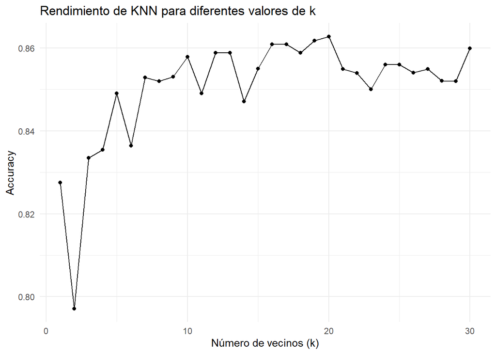

```r
# Graficar el rendimiento para diferentes valores de k
ggplot(knn_cv_model) +
  theme_minimal() +
  labs(title = "Rendimiento de KNN para diferentes valores de k",
       x = "Número de vecinos (k)",
       y = "Accuracy")
```

```r
#ewntrenar el modelo KNN con k = 20
set.seed(123)
knn_model_k20 <- knn(train = train_scaled,
                     test = test_scaled,
                     cl = response,
                     k = 20)


test_encoded$Pred_KNN_k20 <- knn_model_k20


cm_k20 <- confusionMatrix(test_encoded$Pred_KNN_k20, test_encoded$CategoriaPrecio)

print(cm_k20)
```

```
## Confusion Matrix and Statistics
##
##           Reference
## Prediction barata estandar cara
##   barata      131       27    6
##   estandar     10      112    9
##   cara          0        7  134
##
## Overall Statistics
##
##                Accuracy : 0.8647
##                  95% CI : (0.8289, 0.8954)
##     No Information Rate : 0.3417
##     P-Value [Acc > NIR] : < 2.2e-16
##
##                   Kappa : 0.7972
##
##  Mcnemar's Test P-Value : 0.002824
##
## Statistics by Class:
##
##                      Class: barata Class: estandar Class: cara
## Sensitivity                 0.9291          0.7671      0.8993
## Specificity                 0.8881          0.9345      0.9756
## Pos Pred Value              0.7988          0.8550      0.9504
## Neg Pred Value              0.9632          0.8885      0.9492
## Prevalence                  0.3234          0.3349      0.3417
## Detection Rate              0.3005          0.2569      0.3073
## Detection Prevalence        0.3761          0.3005      0.3234
## Balanced Accuracy           0.9086          0.8508      0.9375
```

```r
cat("Accuracy (k = 20):", cm_k20$overall["Accuracy"], "\n")
```

```
## Accuracy (k = 20): 0.8646789
```

Aca podemos ver una gran cantidad de resultados distintos. En este caso nos enfocamos principalmente en el tuning de el parametro K, que es la cantidad de vecions k. Para poder tunear el modelo hicimos que se hiciera una entranmiento con una grilla de valores para k. Probamos con valores de k, desde 1 a 30 con un step de 1 para obtener una gráfica que relaciona el número de vecinos con el accuracy luego del entrenamiento con cada uno de los distintos valores. Dentro del tuning se puede ver que los mejores resuiltados se encuentran con un valor k de 20 o 19. Siendo el de 20 el más alto con un accuracy de 0.8627.

10.Compare la eficiencia del algoritmo con el resultado obtenido con el árbol de decisión (el de clasificación), el modelo de random forest y el de naive bayes que hizo en las entregas pasadas. ¿Cuál es mejor para predecir? ¿Cuál se demoró más en procesar?

Por fines prácticos esta comparación se realizará en el documento de la entrega final, ya que los resultados de cada uno de los métodos se encuentran en distintos archivos y bajo largos análisis con múltiples lineas de código que alargarían demasiado este mismo archivo.